# MCMC方法初步

王宁宁

Tuesday, May 26, 2015

假设$X\sim \pi(x)$，MC算法是利用分布$\pi$的随机数来计算E(f(X))，而MCMC是构造一个稳定分布是$\pi$的马氏链来估计E(f(X))

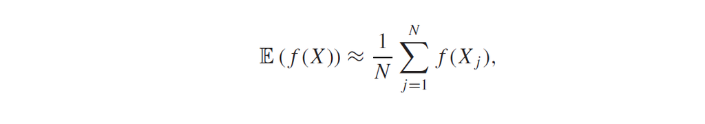

MCMC的实现算法有几十种之多，具体可以看[这里](http://www.bayesian-inference.com/mcmc)。

下面考虑一个简单的使用 Metropolis–Hastings算法的例子：使用MCMC估计古典一元回归模型（三个参数）：

Y=aX+b

设定模型的真值：

```r
trueA <- 5
trueB <- 0
trueSd <- 10
sampleSize <- 31
set.seed(6111)
```

模拟数据：

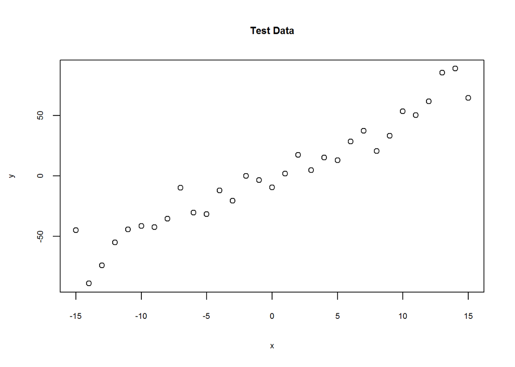

```r
# create independent x-values
x <- (-(sampleSize-1)/2):((sampleSize-1)/2)
# create dependent values according to ax + b + N(0,sd)
y <-  trueA * x + trueB + rnorm(n=sampleSize,mean=0,sd=trueSd)
win.graph(width=9.875, height=7.5,pointsize=8)
plot(x,y, main="Test Data")
```

模型有三个参数：a，b，sd

对数似然函数：

```r
likelihood <- function(param){
  a = param[1]
  b = param[2]
  sd = param[3]

  pred = a*x + b
  singlelikelihoods = dnorm(y, mean = pred, sd = sd, log = T)
  sumll = sum(singlelikelihoods)
  return(sumll)
}
```

似然函数的图形：（为简便起见，只考虑第一个参数的似然函数，其余两个参数代入真值。）

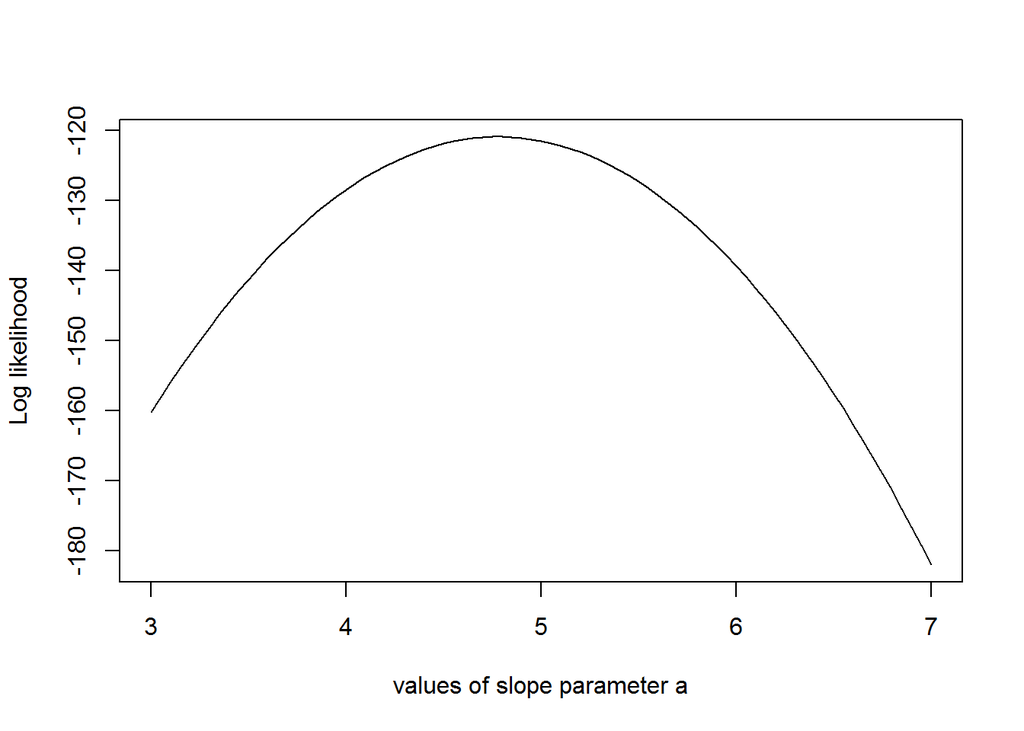

```r
# plot the likelihood profile of the slope a
slopevalues <- function(x){return(likelihood(c(x, trueB, trueSd)))}
slopelikelihoods <- lapply(seq(3, 7, by=.05), slopevalues )
plot (seq(3, 7, by=.05), slopelikelihoods , type="l", xlab = "values of slope parameter a", ylab = "Log likelihood")
```

利用贝叶斯分析估计参数，首先要设定先验：

a：均匀分布U(0,10) b: 正态分布N(0,5^2) sd：均匀分布U(0,30)

```r
prior <- function(param){
  a = param[1]
  b = param[2]
  sd = param[3]
  aprior = dunif(a, min=0, max=10, log = T)
  bprior = dnorm(b, sd = 5, log = T)
  sdprior = dunif(sd, min=0, max=30, log = T)
  return(aprior+bprior+sdprior)
}
```

后验（联合）分布：

```r
posterior <- function(param){
  return (likelihood(param) + prior(param))
}
```

思考：为什么后验分布是这种形式？

Metropolis算法：

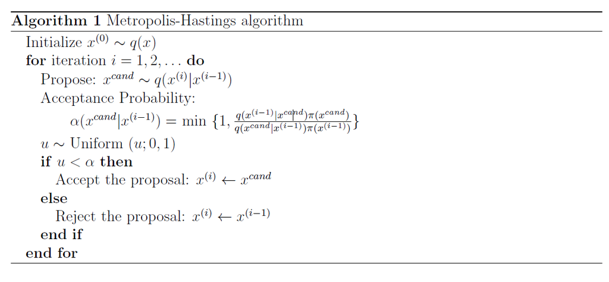

更深入的关于metropolis 算法的介绍可以看这里([Metropolis–Hastings algorithm](http://en.wikipedia.org/wiki/Metropolis%E2%80%93Hastings_algorithm))。

```r
######## Metropolis algorithm ################

proposalfunction <- function(param){
  return(rnorm(3,mean = param, sd= c(0.1,0.5,0.3)))
}#这个是筛选函数

run_metropolis_MCMC <- function(startvalue, iterations){
  chain = array(dim = c(iterations+1,3))
  chain[1,] = startvalue
  for (i in 1:iterations){
    proposal = proposalfunction(chain[i,])
    probab = exp(posterior(proposal) - posterior(chain[i,]))#接收概率
    if (runif(1) < probab){
      chain[i+1,] = proposal
    }else{
      chain[i+1,] = chain[i,]
    }
  }
  return(chain)
}
```

我们这里的筛选接收概率是：prob(new)/prob(old)=exp(log(prob(new))-log(prob(old)))

Metropolis–Hastings算法的关键好处：**取舍函数中，只需要用到后验密度的核**。

运行，设定初始值是（3，3，20），运行10000次，除去前5000次。

```r
startvalue = c(3,3,20)
chain = run_metropolis_MCMC(startvalue, 10000)
burnIn = 5000
#acceptance = 1-mean(duplicated(chain[-(1:burnIn),]))
#acceptance
```

三个参数贝叶斯估计值：

```r
summary(chain[-(1:burnIn),])
```

```
##        V1              V2                 V3
##  Min.   :3.828   Min.   :-4.94857   Min.   : 8.28
##  1st Qu.:4.606   1st Qu.: 0.02505   1st Qu.:11.30
##  Median :4.774   Median : 1.26409   Median :12.31
##  Mean   :4.762   Mean   : 1.31043   Mean   :12.48
##  3rd Qu.:4.922   3rd Qu.: 2.56891   3rd Qu.:13.59
##  Max.   :5.867   Max.   : 7.01348   Max.   :17.49
```

结果展示：

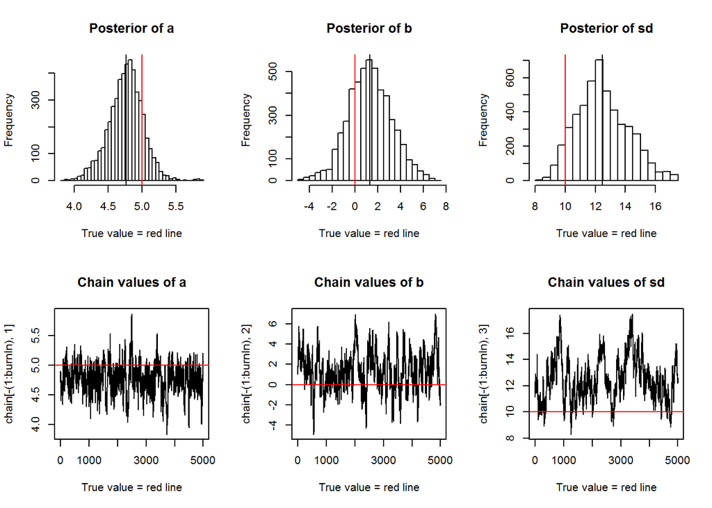

```r
par(mfrow = c(2,3))
hist(chain[-(1:burnIn),1],nclass=30, , main="Posterior of a", xlab="True value = red line" )
abline(v = mean(chain[-(1:burnIn),1]))
abline(v = trueA, col="red" )
hist(chain[-(1:burnIn),2],nclass=30, main="Posterior of b", xlab="True value = red line")
abline(v = mean(chain[-(1:burnIn),2]))
abline(v = trueB, col="red" )
hist(chain[-(1:burnIn),3],nclass=30, main="Posterior of sd", xlab="True value = red line")
abline(v = mean(chain[-(1:burnIn),3]) )
abline(v = trueSd, col="red" )
plot(chain[-(1:burnIn),1], type = "l", xlab="True value = red line" , main = "Chain values of a", )
abline(h = trueA, col="red" )
plot(chain[-(1:burnIn),2], type = "l", xlab="True value = red line" , main = "Chain values of b", )
abline(h = trueB, col="red" )
plot(chain[-(1:burnIn),3], type = "l", xlab="True value = red line" , main = "Chain values of sd", )
abline(h = trueSd, col="red" )
```

与OLS对比：

```r
summary(lm(y~x))
```

```
##
## Call:
## lm(formula = y ~ x)
##
## Residuals:
##      Min       1Q   Median       3Q      Max
## -23.0609  -8.4131  -0.5374   5.6241  25.8757
##
## Coefficients:
##             Estimate Std. Error t value Pr(>|t|)
## (Intercept)   1.1119     2.1538   0.516     0.61
## x             4.7809     0.2408  19.854   <2e-16 ***
## ---
## Signif. codes:  0 '***' 0.001 '**' 0.01 '*' 0.05 '.' 0.1 ' ' 1
##
## Residual standard error: 11.99 on 29 degrees of freedom
## Multiple R-squared:  0.9315, Adjusted R-squared:  0.9291
## F-statistic: 394.2 on 1 and 29 DF,  p-value: < 2.2e-16
```